# Introducción al Aprendizaje Estadístico

**[Marcelo Araya-Salas](https://marce10.github.io/baRulho/)**  
Universidad de Costa Rica

https://marce10.github.io/aprendizaje_estadistico_2024/

## ¿Qué es el Aprendizaje Estadístico?

- Utilización de datos para modelar fenómenos, hacer predicciones y tomar decisiones basadas en la información extraída
- Combina teorías estadísticas con algoritmos computacionales

## ¿Qué es el Aprendizaje Estadístico?

[figure not shown]

**Inteligencia Artificial**: hacer tareas que requieren inteligencia humana

**Aprendizaje estadístico**: uso de algoritmos para analizar datos, aprender de ellos, y hacer predicciones

## ¿Qué es el Aprendizaje Estadístico?

[figure not shown]

**Inteligencia Artificial**: hacer tareas que requieren inteligencia humana

**Aprendizaje estadístico**: uso de algoritmos para analizar datos, aprender de ellos, y hacer predicciones

**Aprendizaje Profundo**: uso de redes neuronales profundas para analizar diversos niveles de abstracción en los datos

**Ciencia de Datos**: técnicas de análisis, procesamiento, y visualización de datos para extraer información/conocimiento de grandes volúmenes de datos

## ¿Qué es el Aprendizaje Estadístico?

$$Y = f(X) + E$$

- Y: variable dependiente (se quiere predecir o explicar)
- X: variable(s) independiente(s) con información relevante para predecir Y
- E: error no reducible

## ¿Qué es el Aprendizaje Estadístico?

$$Y = f(X) + E$$

- sinónimos de Y: variable dependiente, resultado (outcome), etiqueta, objetivo, etc.
- sinónimos de X: variable independiente, atributo (feature), dimensión, predictor, entrada (input), etc.

## ¿Para que Estimar f(X)?

$$Y = f(X) + E$$

- **Predicción**: predecir valores futuros de Y
- **Inferencia**: establecer una relación causal (*i.e. estimar el efecto de un cambio en X sobre el cambio en Y*)

**Aprendizaje estadístico = estimar f(X)**

## Aplicaciones

Omnipresente en herramientas electrónicas:

- **Detección de correo spam**: busca patrones en el contenido del mensaje, como palabras clave sospechosas y comportamientos de envío
- **Reconocimeinto facial**: analiza las características faciales desde diferentes ángulos y aprenden a reconocer variaciones sutiles en la apariencia de un individuo
- **Optimización de Rutas con GPS**: usa los patrones de tráfico históricos y en tiempo real para predecir y sugerir las rutas más rápidas o eficientes

## Aplicaciones en Ciencias Cognoscitivas

Crucial para entender cómo procesamos la información, tomamos decisiones y aprendemos. Algunos sub-campos que utilizan estas herramientas:

- **Neurociencia Cognitiva**: Identificación de patrones en la actividad cerebral relacionados con diferentes funciones cognitivas
- **Psicología Experimental**: Modelado de comportamiento humano y predicción de respuestas psicológicas
- **Neurociencia Computacional**: Modelado de la actividad neuronal para simular procesos cerebrales

[figure not shown]

### Aplicaciones: Memoria

- Roediger et al 2001. [Factors that determine false recall: A multiple regression analysis](https://link.springer.com/content/pdf/10.3758/bf03196177.pdf)
- Regresión multiple para identificar factores que influyen en el recuerdo falso
- Recuerdo verídico (r = -0.43) y la fuerza de la asociación entre items (r = 0.73) influyen

[figure not shown]

$Y: recuerdo\ falso \sim X: asociacion\ entre\ items + recuerdo\ verídico + ...$

### Aplicaciones: Reconocimiento de Emociones

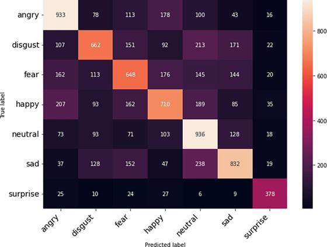

$Y: emoción \sim X: estructura\ acústica$

### Aplicaciones: Resilencia al Estrés

- Chen et al. 2023. [*Identifying the top determinants of psychological resilience among community older adults during COVID-19 in Taiwan: A random forest approach*](https://www.sciencedirect.com/science/article/pii/S2666827023000476)
- Factores que determinan la resiliencia al estrés
- 80% de probabilidad de una predición correcta

[figure not shown]

$Y:resilencia\ (binaria) \sim X: género + edad + educación + ...$

## Tipos de Modelos

**Supervisado**: Se predice una Y conocida *a priori*

$$Y = f(X)$$

| Y | X1 | X2 | X3 |
| --- | --- | --- | --- |
| -0.56 | 1.72 | 1.22 | 1.79 |
| -0.23 | 0.46 | 0.36 | 0.50 |
| 1.56 | -1.27 | 0.40 | -1.97 |
| 0.07 | -0.69 | 0.11 | 0.70 |
| 0.13 | -0.45 | -0.56 | -0.47 |

## Tipos de Modelos

**Supervisado**: Se predice una Y conocida *a priori*

$$Y = f(X)$$

| Y | X1 | X2 | X3 |
| --- | --- | --- | --- |
| A | -0.55 | -1.60 | -0.83 |
| C | -0.02 | 0.66 | -0.62 |
| B | -0.58 | -1.87 | -0.29 |
| C | 1.07 | 0.26 | -0.50 |
| A | 1.04 | -0.22 | 1.10 |

## Tipos de Modelos

**No supervisado**: genera una Y con base en la estructura de X

$$f(X)$$

| Y | X1 | X2 | X3 |
| --- | --- | --- | --- |
| ? | -0.56 | 1.72 | 1.22 |
| ? | -0.23 | 0.46 | 0.36 |
| ? | 1.56 | -1.27 | 0.40 |
| ? | 0.07 | -0.69 | 0.11 |
| ? | 0.13 | -0.45 | -0.56 |

## Tipos de Modelos

**No supervisado**: ó explora la estructura de X

$$f(X)$$

| X1 | X2 | X3 |
| --- | --- | --- |
| -0.56 | 1.72 | 1.22 |
| -0.23 | 0.46 | 0.36 |
| 1.56 | -1.27 | 0.40 |
| 0.07 | -0.69 | 0.11 |
| 0.13 | -0.45 | -0.56 |

## Escogiendo el Modelo Adecuado

¿Existe Y?

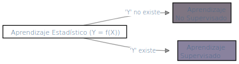

## Escogiendo el Modelo Adecuado

Si Y existe ¿Es continua o categórica?

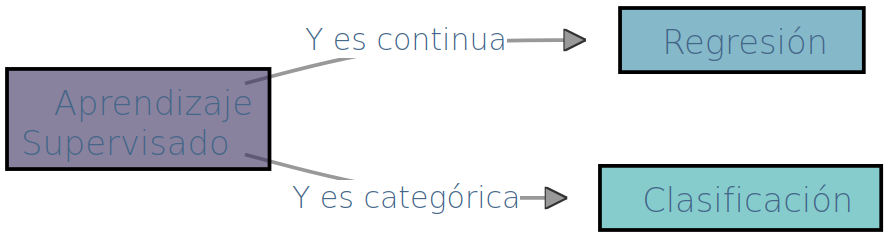

## Escogiendo el Modelo Adecuado

Si Y no existe ¿Queremos generarla o solo explorar X?

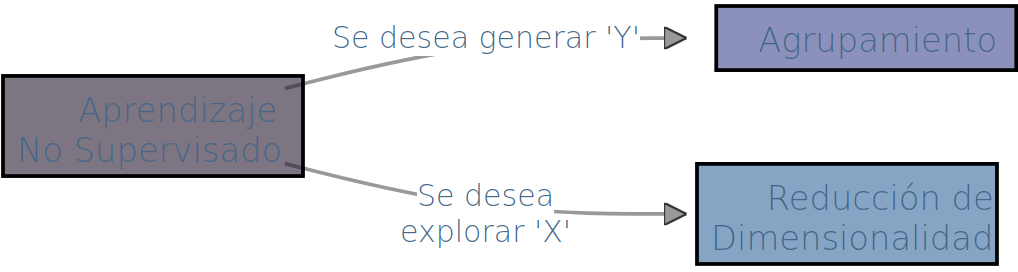

## Escogiendo el Modelo Adecuado

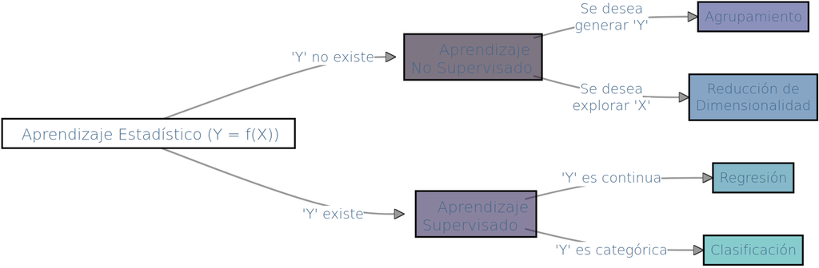

## Escogiendo el Modelo Adecuado

[figure not shown]

## Escogiendo el Modelo Adecuado

Interpretabilidad

[*Tomado de Badillo et al 2020*](https://ascpt.onlinelibrary.wiley.com/doi/pdfdirect/10.1002/cpt.1796)

[figure not shown]

# Introducción al Aprendizaje Estadístico

**[Marcelo Araya-Salas](https://marce10.github.io/baRulho/)**  
Universidad de Costa Rica

https://marce10.github.io/aprendizaje_estadistico_2024/